# Home 4: Build a seq2seq model for machine translation.

### Name: [Zhipeng Lin]

### Task: Translate English to [French and Spanish]

```python
from google.colab import drive
drive.mount('/content/drive')
```

[output not shown]

## 0. You will do the following:

1. Read and run my code.
2. Complete the code in Section 1.1 and Section 4.2.
   - Translation English to **German** is not acceptable!!! Try another language.
3. **Make improvements.** Directly modify the code in Section 3. Do at least one of the followings. By doing more, you will get up to 2 bonus scores to the total.
   - Bi-LSTM instead of LSTM
   - Multi-task learning (e.g., both English to French and English to Spanish)
   - Attention
4. Evaluate the translation using the BLEU score.
   - Optional. Up to 1 bonus scores to the total.
5. Convert the notebook to .HTML file.
   - The HTML file must contain the code and the output after execution.
6. Put the .HTML file in your Google Drive, Dropbox, or Github repo.
7. Submit the link to the HTML file to Canvas.

### Hint:

To implement `Bi-LSTM`, you will need the following code to build the encoder; the decoder won't be much different.

```python
# from keras.layers import Bidirectional, Concatenate

# encoder_bilstm = Bidirectional(LSTM(latent_dim, return_state=True,
#                                   dropout=0.5, name='encoder_lstm'))
# _, forward_h, forward_c, backward_h, backward_c = encoder_bilstm(encoder_inputs)

# state_h = Concatenate()([forward_h, backward_h])
# state_c = Concatenate()([forward_c, backward_c])
```

### Hint:

To implement multi-task training, you can refer to `Section 7.1.3 Multi-output models` of the textbook, `Deep Learning with Python`.

## 1. Data preparation

1. Download data (e.g., "deu-eng.zip") from http://www.manythings.org/anki/
2. Unzip the .ZIP file.
3. Put the .TXT file (e.g., "deu.txt") in the directory "./Data/".

### 1.1. Load and clean text

```python
import re
import string
from unicodedata import normalize
import numpy

# load doc into memory
def load_doc(filename):
    # open the file as read only
    file = open(filename, mode='rt', encoding='utf-8')
    # read all text
    text = file.read()
    # close the file
    file.close()
    return text


# split a loaded document into sentences
def to_pairs(doc):
    lines = doc.strip().split('\n')
    pairs = [line.split('\t') for line in  lines]
    return pairs

def clean_data(lines):
    cleaned = list()
    # prepare regex for char filtering
    re_print = re.compile('[^%s]' % re.escape(string.printable))
    # prepare translation table for removing punctuation
    table = str.maketrans('', '', string.punctuation)
    for pair in lines:
        clean_pair = list()
        for line in pair:
            # normalize unicode characters
            line = normalize('NFD', line).encode('ascii', 'ignore')
            line = line.decode('UTF-8')
            # tokenize on white space
            line = line.split()
            # convert to lowercase
            line = [word.lower() for word in line]
            # remove punctuation from each token
            line = [word.translate(table) for word in line]
            # remove non-printable chars form each token
            line = [re_print.sub('', w) for w in line]
            # remove tokens with numbers in them
            line = [word for word in line if word.isalpha()]
            # store as string
            clean_pair.append(' '.join(line))
        cleaned.append(clean_pair)
    return numpy.array(cleaned)
```

#### Fill the following blanks:

```python
# e.g., filename = 'Data/deu.txt'
filename1 = '/content/drive/My Drive/CS583/hw4/fra.txt'
filename2 = '/content/drive/My Drive/CS583/hw4/spa.txt'

# e.g., n_train = 20000
n_train = 20000
```

```python
# load dataset
doc1 = load_doc(filename1)
doc2 = load_doc(filename2)

# split into Language1-Language2 pairs
pairs1 = to_pairs(doc1)
pairs2 = to_pairs(doc2)

# clean sentences
clean_pairs1 = clean_data(pairs1)[0:n_train, :]
clean_pairs2 = clean_data(pairs2)[0:n_train, :]
```

```python
for i in range(3000, 3010):
    print('[' + clean_pairs1[i, 0] + '] => [' + clean_pairs1[i, 1] + ']')
    print('[' + clean_pairs2[i, 0] + '] => [' + clean_pairs2[i, 1] + ']')
```

```
[whats that] => [quest cela]
[i loved that] => [eso me gusto]
[whats this] => [questce que cest]
[i loved that] => [eso me gustaba]
[whats this] => [cest quoi]
[i loved that] => [a mi me gustaba eso]
[whats this] => [cest quoi ca]
[i made a bet] => [hice una apuesta]
[where is he] => [ou estil]
[i made these] => [yo hice estos]
[where is it] => [ou estil]
[i made these] => [estos los hice yo]
[where is it] => [ou estelle]
[i misled tom] => [yo engane a tom]
[where was i] => [ou en etaisje]
[i missed you] => [te eche de menos]
[where was i] => [ou etaisje]
[i missed you] => [te extrane]
[wheres tom] => [ou est tom]
[i need a cab] => [necesito un taxi]
```

```python
len(pairs1),len(pairs2)
```

```
(170651, 122936)
```

```python
# fetch data from both
c = 0
target_texts1 = []
target_texts2 = []
input_texts = []
for i in clean_pairs1[0:20000]:
  for j in clean_pairs2[0:20000]:
    if i[0] == j[0]:
      c+=1
      target_texts1_list = i[1]
      target_texts2_list = j[1]

      # print(target_texts1_list,'1',target_texts2_list,'2',i[0])

      input_texts.append(i[0])
      target_texts1.append(target_texts1_list)
      target_texts2.append(target_texts2_list)

      if c %100 ==0:
        print(c)
      break
c
```

[output not shown]

[output cut: 47 more lines]

```
8800
8900
9000
9100
9200
9300
9400
9500
9600
9700
9800
9900
10000
10100
10200
```

```
10228
```

```python
target_texts1 = ['\t' + text + '\n' for text in target_texts1]
target_texts2 = ['\t' + text + '\n' for text in target_texts2]

len(target_texts1),len(target_texts2),len(input_texts)
```

```
(10228, 10228, 10228)
```

```python
# input_texts = clean_pairs[:, 0]
# target_texts = ['\t' + text + '\n' for text in clean_pairs[:, 1]]

# print('Length of input_texts:  ' + str(input_texts.shape))
# print('Length of target_texts: ' + str(input_texts.shape))
```

```python
max_encoder_seq_length = max(len(line) for line in input_texts)
max_decoder_seq_length1 = max(len(line) for line in target_texts1)
max_decoder_seq_length2 = max(len(line) for line in target_texts2)

print('max length of input  sentences: %d' % (max_encoder_seq_length))
print('max length of target1 sentences: %d' % (max_decoder_seq_length1))
print('max length of target2 sentences: %d' % (max_decoder_seq_length2))
```

```
max length of input  sentences: 17
max length of target1 sentences: 56
max length of target2 sentences: 43
```

**Remark:** To this end, you have two lists of sentences: input_texts and target_texts

## 2. Text processing

### 2.1. Convert texts to sequences

- Input: A list of $n$ sentences (with max length $t$).
- It is represented by a $n\times t$ matrix after the tokenization and zero-padding.

```python
from keras.preprocessing.text import Tokenizer
from keras.preprocessing.sequence import pad_sequences

# encode and pad sequences
def text2sequences(max_len, lines):
    tokenizer = Tokenizer(char_level=True, filters='')
    tokenizer.fit_on_texts(lines)
    seqs = tokenizer.texts_to_sequences(lines)
    seqs_pad = pad_sequences(seqs, maxlen=max_len, padding='post')
    return seqs_pad, tokenizer.word_index


encoder_input_seq, input_token_index = text2sequences(max_encoder_seq_length,
                                                      input_texts)
decoder_input_seq1, target_token_index1 = text2sequences(max_decoder_seq_length1,
                                                       target_texts1)
decoder_input_seq2, target_token_index2 = text2sequences(max_decoder_seq_length2,
                                                       target_texts2)


print('shape of encoder_input_seq: ' + str(encoder_input_seq.shape))
print('shape of input_token_index: ' + str(len(input_token_index)))
print('shape of decoder_input_seq1: ' + str(decoder_input_seq1.shape))
print('shape of target_token_index1: ' + str(len(target_token_index1)))
print('shape of decoder_input_seq2: ' + str(decoder_input_seq2.shape))
print('shape of target_token_index2: ' + str(len(target_token_index2)))
```

```
shape of encoder_input_seq: (10228, 17)
shape of input_token_index: 27
shape of decoder_input_seq1: (10228, 56)
shape of target_token_index1: 29
shape of decoder_input_seq2: (10228, 43)
shape of target_token_index2: 29
```

```python
num_encoder_tokens = len(input_token_index) + 1
num_decoder_tokens1 = len(target_token_index1) + 1
num_decoder_tokens2 = len(target_token_index2) + 1


print('num_encoder_tokens: ' + str(num_encoder_tokens))
print('num_decoder_tokens1: ' + str(num_decoder_tokens1))
print('num_decoder_tokens2: ' + str(num_decoder_tokens2))
```

```
num_encoder_tokens: 28
num_decoder_tokens1: 30
num_decoder_tokens2: 30
```

**Remark:** To this end, the input language and target language texts are converted to 2 matrices.

The followings print a sentence and its representation as a sequence.

```python
target_texts1[50],target_texts2[50]
```

```
('\ten aucun cas\n', '\tno puede ser\n')
```

```python
decoder_input_seq1[100, :]
```

```
array([ 7, 13,  4,  5,  3,  3,  1, 13,  1,  2,  6, 11, 14, 21,  1, 12,  8,
        0,  0,  0,  0,  0,  0,  0,  0,  0,  0,  0,  0,  0,  0,  0,  0,  0,
        0,  0,  0,  0,  0,  0,  0,  0,  0,  0,  0,  0,  0,  0,  0,  0,  0,
        0,  0,  0,  0,  0], dtype=int32)
```

## 2.2. One-hot encode

- Input: A list of $n$ sentences (with max length $t$).
- It is represented by a $n\times t$ matrix after the tokenization and zero-padding.
- It is represented by a $n\times t \times v$ tensor ($t$ is the number of unique chars) after the one-hot encoding.

```python
from keras.utils import to_categorical

# one hot encode target sequence
def onehot_encode(sequences, max_len, vocab_size):
    n = len(sequences)
    data = numpy.zeros((n, max_len, vocab_size))
    for i in range(n):
        data[i, :, :] = to_categorical(sequences[i], num_classes=vocab_size)
    return data

encoder_input_data = onehot_encode(encoder_input_seq, max_encoder_seq_length, num_encoder_tokens)
decoder_input_data1 = onehot_encode(decoder_input_seq1, max_decoder_seq_length1, num_decoder_tokens1)
decoder_input_data2 = onehot_encode(decoder_input_seq2, max_decoder_seq_length2, num_decoder_tokens2)

decoder_target_seq1 = numpy.zeros(decoder_input_seq1.shape)
decoder_target_seq1[:, 0:-1] = decoder_input_seq1[:, 1:]
decoder_target_data1 = onehot_encode(decoder_target_seq1,
                                    max_decoder_seq_length1,
                                    num_decoder_tokens1)

decoder_target_seq2 = numpy.zeros(decoder_input_seq2.shape)
decoder_target_seq2[:, 0:-1] = decoder_input_seq2[:, 1:]
decoder_target_data2 = onehot_encode(decoder_target_seq2,
                                    max_decoder_seq_length2,
                                    num_decoder_tokens2)


print(encoder_input_data.shape)
print(decoder_input_data1.shape)
print(decoder_input_data2.shape)
```

```
(10228, 17, 28)
(10228, 56, 30)
(10228, 43, 30)
```

## 3. Build the networks (for training)

- Build encoder, decoder, and connect the two modules to get "model".
- Fit the model on the bilingual data to train the parameters in the encoder and decoder.

### 3.1. Encoder network

- Input: one-hot encode of the input language
- Return:

  -- output (all the hidden states $h_1, \cdots , h_t$) are always discarded

  -- the final hidden state $h_t$

  -- the final conveyor belt $c_t$

```python
from keras.layers import Input, LSTM, Bidirectional, Concatenate
from keras.models import Model

latent_dim = 256

# inputs of the encoder network
encoder_inputs = Input(shape=(None, num_encoder_tokens),
                       name='encoder_inputs')

# set the LSTM layer
encoder_lstm = Bidirectional(LSTM(latent_dim, return_state=True,
                    dropout=0.5, name='encoder_lstm'))
_, forward_h, backward_h, forward_c, backward_c = encoder_lstm(encoder_inputs)
# _, state_h, state_c = encoder_lstm(encoder_inputs)

state_h = Concatenate()([forward_h, backward_h])
state_c = Concatenate()([forward_c, backward_c])

# build the encoder network model
encoder_model = Model(inputs=encoder_inputs,
                      # outputs=[forward_h,  backward_h,forward_c, backward_c],
                      outputs = [state_h,state_c],
                      name='encoder')
```

[output not shown]

Print a summary and save the encoder network structure to "./encoder.pdf"

```python
from IPython.display import SVG
from keras.utils.vis_utils import model_to_dot, plot_model

SVG(model_to_dot(encoder_model, show_shapes=False).create(prog='dot', format='svg'))

plot_model(
    model=encoder_model, show_shapes=False,
    # to_file='encoder.pdf'
)

encoder_model.summary()
```

```
Model: "encoder"
__________________________________________________________________________________________________
Layer (type)                    Output Shape         Param #     Connected to
==================================================================================================
encoder_inputs (InputLayer)     (None, None, 28)     0
__________________________________________________________________________________________________
bidirectional_1 (Bidirectional) [(None, 512), (None, 583680      encoder_inputs[0][0]
__________________________________________________________________________________________________
concatenate_1 (Concatenate)     (None, 512)          0           bidirectional_1[0][1]
                                                                 bidirectional_1[0][2]
__________________________________________________________________________________________________
concatenate_2 (Concatenate)     (None, 512)          0           bidirectional_1[0][3]
                                                                 bidirectional_1[0][4]
==================================================================================================
Total params: 583,680
Trainable params: 583,680
Non-trainable params: 0
__________________________________________________________________________________________________
```

### 3.2. Decoder network

- Inputs:

  -- one-hot encode of the target language

  -- The initial hidden state $h_t$

  -- The initial conveyor belt $c_t$
- Return:

  -- output (all the hidden states) $h_1, \cdots , h_t$

  -- the final hidden state $h_t$ (discarded in the training and used in the prediction)

  -- the final conveyor belt $c_t$ (discarded in the training and used in the prediction)

```python
from keras.layers import Input, LSTM, Dense
from keras.models import Model

# inputs of the decoder network
decoder_input_h = Input(shape=(latent_dim*2,), name='decoder_input_h')
decoder_input_c = Input(shape=(latent_dim*2,), name='decoder_input_c')
decoder_input_x = Input(shape=(None, num_decoder_tokens), name='decoder_input_x')

# set the LSTM layer
decoder_lstm = LSTM(latent_dim*2, return_sequences=True,
                    return_state=True, dropout=0.5, name='decoder_lstm')
decoder_lstm_outputs, state_h, state_c = decoder_lstm(decoder_input_x,
                                                      initial_state=[decoder_input_h, decoder_input_c])

# set the dense layer
decoder_dense = Dense(num_decoder_tokens, activation='softmax', name='decoder_dense')
decoder_outputs = decoder_dense(decoder_lstm_outputs)

# build the decoder network model
decoder_model = Model(inputs=[decoder_input_x, decoder_input_h, decoder_input_c],
                      outputs=[decoder_outputs, state_h, state_c],
                      name='decoder')
```

multi

```python
from keras.layers import Input, LSTM, Dense
from keras.models import Model
# decoder1
# inputs of the decoder network
decoder_input_h = Input(shape=(latent_dim*2,), name='decoder_input_h')
decoder_input_c = Input(shape=(latent_dim*2,), name='decoder_input_c')
decoder_input_x1 = Input(shape=(None, num_decoder_tokens1), name='decoder_input_x1')

# set the LSTM layer
decoder_lstm1 = LSTM(latent_dim*2, return_sequences=True,
                    return_state=True, dropout=0.5, name='decoder_lstm1')
decoder_lstm_outputs, state_h, state_c = decoder_lstm1(decoder_input_x1,
                                                      initial_state=[decoder_input_h, decoder_input_c])

# set the dense layer
decoder_dense1 = Dense(num_decoder_tokens1, activation='softmax', name='decoder_dense1')
decoder_outputs = decoder_dense1(decoder_lstm_outputs)

# build the decoder network model
decoder_model1 = Model(inputs=[decoder_input_x1, decoder_input_h, decoder_input_c],
                      outputs=[decoder_outputs, state_h, state_c],
                      # outputs=[decoder_lstm_outputs, state_h, state_c],
                      name='decoder1')
```

```python
# decoder2
# inputs of the decoder network
decoder_input_h = Input(shape=(latent_dim*2,), name='decoder_input_h')
decoder_input_c = Input(shape=(latent_dim*2,), name='decoder_input_c')
decoder_input_x2 = Input(shape=(None, num_decoder_tokens2), name='decoder_input_x2')

# set the LSTM layer
decoder_lstm2 = LSTM(latent_dim*2, return_sequences=True,
                    return_state=True, dropout=0.5, name='decoder_lstm2')
decoder_lstm_outputs, state_h, state_c = decoder_lstm2(decoder_input_x2,
                                                      initial_state=[decoder_input_h, decoder_input_c])

# set the dense layer
decoder_dense2 = Dense(num_decoder_tokens2, activation='softmax', name='decoder_dense2')
decoder_outputs = decoder_dense2(decoder_lstm_outputs)

decoder_model2 = Model(inputs=[decoder_input_x2, decoder_input_h, decoder_input_c],
                      outputs=[decoder_outputs, state_h, state_c],
                      # outputs=[decoder_lstm_outputs, state_h, state_c],
                      name='decoder2')
```

Print a summary and save the encoder network structure to "./decoder.pdf"

```python
from IPython.display import SVG
from keras.utils.vis_utils import model_to_dot, plot_model

SVG(model_to_dot(decoder_model1, show_shapes=False).create(prog='dot', format='svg'))

plot_model(
    model=decoder_model1, show_shapes=False,
    # to_file='decoder.pdf'
)

decoder_model1.summary()
decoder_model2.summary()
```

```
Model: "decoder1"
__________________________________________________________________________________________________
Layer (type)                    Output Shape         Param #     Connected to
==================================================================================================
decoder_input_x1 (InputLayer)   (None, None, 30)     0
__________________________________________________________________________________________________
decoder_input_h (InputLayer)    (None, 512)          0
__________________________________________________________________________________________________
decoder_input_c (InputLayer)    (None, 512)          0
__________________________________________________________________________________________________
decoder_lstm1 (LSTM)            [(None, None, 512),  1112064     decoder_input_x1[0][0]
                                                                 decoder_input_h[0][0]
                                                                 decoder_input_c[0][0]
__________________________________________________________________________________________________
decoder_dense1 (Dense)          (None, None, 30)     15390       decoder_lstm1[0][0]
==================================================================================================
Total params: 1,127,454
Trainable params: 1,127,454
Non-trainable params: 0
__________________________________________________________________________________________________
Model: "decoder2"
__________________________________________________________________________________________________
Layer (type)                    Output Shape         Param #     Connected to
==================================================================================================
decoder_input_x2 (InputLayer)   (None, None, 30)     0
__________________________________________________________________________________________________
decoder_input_h (InputLayer)    (None, 512)          0
__________________________________________________________________________________________________
decoder_input_c (InputLayer)    (None, 512)          0
__________________________________________________________________________________________________
decoder_lstm2 (LSTM)            [(None, None, 512),  1112064     decoder_input_x2[0][0]
                                                                 decoder_input_h[0][0]
                                                                 decoder_input_c[0][0]
__________________________________________________________________________________________________
decoder_dense2 (Dense)          (None, None, 30)     15390       decoder_lstm2[0][0]
==================================================================================================
Total params: 1,127,454
Trainable params: 1,127,454
Non-trainable params: 0
__________________________________________________________________________________________________
```

### 3.3. Connect the encoder and decoder

```python
# input layers
encoder_input_x = Input(shape=(None, num_encoder_tokens), name='encoder_input_x')
decoder_input_x1 = Input(shape=(None, num_decoder_tokens1), name='decoder_input_x1')
decoder_input_x2 = Input(shape=(None, num_decoder_tokens2), name='decoder_input_x2')

# connect encoder to decoder
encoder_final_states = encoder_model([encoder_input_x])
# encoder_final_states_h,encoder_final_states_c = encoder_model([encoder_input_x])

decoder_lstm_output1, _, _ = decoder_lstm1(decoder_input_x1, initial_state=encoder_final_states)
decoder_pred1 = decoder_dense1(decoder_lstm_output1)
decoder_lstm_output2, _, _ = decoder_lstm2(decoder_input_x2, initial_state=encoder_final_states)
decoder_pred2 = decoder_dense2(decoder_lstm_output2)

# decoder_pred1 = decoder_model1(decoder_input_x1,encoder_final_states )
# decoder_pred2 = decoder_model2(decoder_input_x2,encoder_final_states )

model = Model(inputs=[encoder_input_x, decoder_input_x1,decoder_input_x2],
              outputs=[decoder_pred1, decoder_pred2],
              name='model_training')
```

```python
from IPython.display import SVG
from keras.utils.vis_utils import model_to_dot, plot_model

SVG(model_to_dot(model, show_shapes=False).create(prog='dot', format='svg'))

plot_model(
    model=model, show_shapes=False,
    to_file='model_training.jpeg'
)

model.summary()
```

```
Model: "model_training"
__________________________________________________________________________________________________
Layer (type)                    Output Shape         Param #     Connected to
==================================================================================================
encoder_input_x (InputLayer)    (None, None, 28)     0
__________________________________________________________________________________________________
decoder_input_x1 (InputLayer)   (None, None, 30)     0
__________________________________________________________________________________________________
encoder (Model)                 [(None, 512), (None, 583680      encoder_input_x[0][0]
__________________________________________________________________________________________________
decoder_input_x2 (InputLayer)   (None, None, 30)     0
__________________________________________________________________________________________________
decoder_lstm1 (LSTM)            [(None, None, 512),  1112064     decoder_input_x1[0][0]
                                                                 encoder[1][0]
                                                                 encoder[1][1]
__________________________________________________________________________________________________
decoder_lstm2 (LSTM)            [(None, None, 512),  1112064     decoder_input_x2[0][0]
                                                                 encoder[1][0]
                                                                 encoder[1][1]
__________________________________________________________________________________________________
decoder_dense1 (Dense)          (None, None, 30)     15390       decoder_lstm1[1][0]
__________________________________________________________________________________________________
decoder_dense2 (Dense)          (None, None, 30)     15390       decoder_lstm2[1][0]
==================================================================================================
Total params: 2,838,588
Trainable params: 2,838,588
Non-trainable params: 0
__________________________________________________________________________________________________
```

### 3.5. Fit the model on the bilingual dataset

- encoder_input_data: one-hot encode of the input language
- decoder_input_data: one-hot encode of the input language
- decoder_target_data: labels (left shift of decoder_input_data)
- tune the hyper-parameters
- stop when the validation loss stop decreasing.

```python
print('shape of encoder_input_data' + str(encoder_input_data.shape))
print('shape of decoder_input_data1' + str(decoder_input_data1.shape))
print('shape of decoder_target_data1' + str(decoder_target_data1.shape))
print('shape of decoder_input_data2' + str(decoder_input_data2.shape))
print('shape of decoder_target_data2' + str(decoder_target_data2.shape))
```

```
shape of encoder_input_data(10228, 17, 28)
shape of decoder_input_data1(10228, 56, 30)
shape of decoder_target_data1(10228, 56, 30)
shape of decoder_input_data2(10228, 43, 30)
shape of decoder_target_data2(10228, 43, 30)
```

```python
model.compile(optimizer='rmsprop', loss=['categorical_crossentropy','categorical_crossentropy'])

model.fit([encoder_input_data, decoder_input_data1, decoder_input_data2],  # training data
          [decoder_target_data1, decoder_target_data2],                       # labels (left shift of the target sequences)
          batch_size=64, epochs=50, validation_split=0.2)

model.save('seq2seq.h5')
```

[output not shown]

```python
history = model.history
```

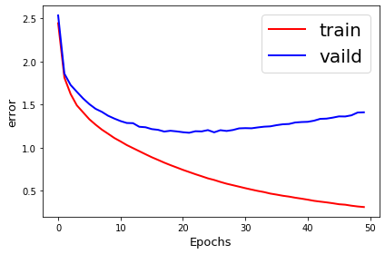

```python
hist_train_loss = history.history['loss']
hist_vaild_loss = history.history['val_loss']
import matplotlib.pyplot as plt
%matplotlib inline
fig = plt.figure(figsize=(6, 4))
epochs_loss = history.epoch

line0, = plt.plot(hist_train_loss, '-r', LineWidth=2)
line1, = plt.plot(hist_vaild_loss,'-b', LineWidth=2)

plt.xlabel('Epochs', FontSize=13)
plt.ylabel('error', FontSize=13)
plt.xticks(FontSize=10)
plt.yticks(FontSize=10)
plt.legend([line0, line1], ['train','vaild'], fontsize=20)
plt.tight_layout()
plt.show()
```

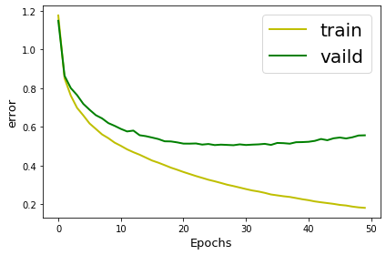

```python
hist_train_loss = history.history['decoder_dense1_loss']
hist_vaild_loss = history.history['val_decoder_dense1_loss']
import matplotlib.pyplot as plt
%matplotlib inline
fig = plt.figure(figsize=(6, 4))
epochs_loss = history.epoch

line0, = plt.plot(hist_train_loss, '-y', LineWidth=2)
line1, = plt.plot(hist_vaild_loss,'-g', LineWidth=2)

plt.xlabel('Epochs', FontSize=13)
plt.ylabel('error', FontSize=13)
plt.xticks(FontSize=10)
plt.yticks(FontSize=10)
plt.legend([line0, line1], ['train','vaild'], fontsize=20)
plt.tight_layout()
plt.show()
```

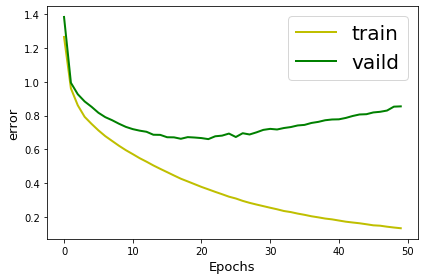

```python
hist_train_loss = history.history['decoder_dense2_loss']
hist_vaild_loss = history.history['val_decoder_dense2_loss']
import matplotlib.pyplot as plt
%matplotlib inline
fig = plt.figure(figsize=(6, 4))
epochs_loss = history.epoch

line0, = plt.plot(hist_train_loss, '-y', LineWidth=2)
line1, = plt.plot(hist_vaild_loss,'-g', LineWidth=2)

plt.xlabel('Epochs', FontSize=13)
plt.ylabel('error', FontSize=13)
plt.xticks(FontSize=10)
plt.yticks(FontSize=10)
plt.legend([line0, line1], ['train','vaild'], fontsize=20)
plt.tight_layout()
plt.show()
```

## 4. Make predictions

1. Encoder read a sentence (source language) and output its final states, $h_t$ and $c_t$.
2. Take the [star] sign "\t" and the final state $h_t$ and $c_t$ as input and run the decoder.
3. Get the new states and predicted probability distribution.
4. sample a char from the predicted probability distribution
5. take the sampled char and the new states as input and repeat the process (stop if reach the [stop] sign "\n").

```python
# Reverse-lookup token index to decode sequences back to something readable.
reverse_input_char_index = dict((i, char) for char, i in input_token_index.items())
reverse_target_char_index1 = dict((i, char) for char, i in target_token_index1.items())
reverse_target_char_index2 = dict((i, char) for char, i in target_token_index2.items())
```

```python
def decode_sequence1(input_seq):
    states_value = encoder_model.predict(input_seq)

    target_seq = numpy.zeros((1, 1, num_decoder_tokens1))
    target_seq[0, 0, target_token_index1['\t']] = 1.

    stop_condition = False
    decoded_sentence = ''
    while not stop_condition:
        output_tokens, h, c = decoder_model1.predict([target_seq]+states_value)
        # a = decoder_model1.predict([target_seq]+states_value)
        # # this line of code is greedy selection
        # # try to use multinomial sampling instead (with temperature)
        sampled_token_index = numpy.argmax(output_tokens[0, -1, :])

        sampled_char = reverse_target_char_index1[sampled_token_index]
        decoded_sentence += sampled_char

        if (sampled_char == '\n' or
           len(decoded_sentence) > max_decoder_seq_length1):
            stop_condition = True

        target_seq = numpy.zeros((1, 1, num_decoder_tokens1))
        target_seq[0, 0, sampled_token_index] = 1.

        states_value = [h, c]
    # return a
    return decoded_sentence
```

```python
def decode_sequence2(input_seq):
    states_value = encoder_model.predict(input_seq)

    target_seq = numpy.zeros((1, 1, num_decoder_tokens2))
    target_seq[0, 0, target_token_index2['\t']] = 1.

    stop_condition = False
    decoded_sentence = ''
    while not stop_condition:
        output_tokens, h, c = decoder_model2.predict([target_seq]+states_value)
        a = decoder_model2.predict([target_seq]+states_value)
        # # this line of code is greedy selection
        # # try to use multinomial sampling instead (with temperature)
        sampled_token_index = numpy.argmax(output_tokens[0, -1, :])

        sampled_char = reverse_target_char_index2[sampled_token_index]
        decoded_sentence += sampled_char

        if (sampled_char == '\n' or
           len(decoded_sentence) > max_decoder_seq_length2):
            stop_condition = True

        target_seq = numpy.zeros((1, 1, num_decoder_tokens2))
        target_seq[0, 0, sampled_token_index] = 1.

        states_value = [h, c]
    # return a
    return decoded_sentence
```

```python
for seq_index in range(2300, 2320):
    # Take one sequence (part of the training set)
    # for trying out decoding.
    input_seq = encoder_input_data[seq_index: seq_index + 1]

    decoded_sentence1 = decode_sequence1(input_seq)
    decoded_sentence2 = decode_sequence2(input_seq)

    print('-')
    print('English:       ', input_texts[seq_index])
    print('Franch (true): ', target_texts1[seq_index][1:-1])
    print('Franch (pred): ', decoded_sentence1[0:-1])
    print('Spanish (true): ', target_texts2[seq_index][1:-1])
    print('Spanish (pred): ', decoded_sentence2[0:-1])
```

```
-
English:        i have a car
Franch (true):  je dispose dune voiture
Franch (pred):  jai un rhime
Spanish (true):  tengo un coche
Spanish (pred):  tengo un coche
-
English:        i have a cat
Franch (true):  jai un chat
Franch (pred):  jai un vant
Spanish (true):  tengo un gato
Spanish (pred):  tengo una cita
-
English:        i have a cat
Franch (true):  jai une chatte
Franch (pred):  jai un vant
Spanish (true):  tengo un gato
Spanish (pred):  tengo una cita
-
English:        i have a dog
Franch (true):  jai un chien
Franch (pred):  jai un chien
Spanish (true):  tengo un perro
Spanish (pred):  tengo un herro
-
English:        i have a key
Franch (true):  je dispose dune cle
Franch (pred):  jai un linu
Spanish (true):  tengo una llave
Spanish (pred):  tengo un coche
-
English:        i have a pen
Franch (true):  jai un stylo
Franch (pred):  jai un rhime
Spanish (true):  tengo una pluma
Spanish (pred):  tengo una visa
-
English:        i have money
Franch (true):  jai de largent
Franch (pred):  jai de largent
```

[output cut: 65 more lines]

```
Franch (pred):  je viens juste de vour
Spanish (true):  acabo de mudarme
Spanish (pred):  acabo de mudarme
-
English:        i just moved
Franch (true):  je viens detre mute
Franch (pred):  je viens juste de vour
Spanish (true):  acabo de mudarme
Spanish (pred):  acabo de mudarme
-
English:        i keep a dog
Franch (true):  jeleve un chien
Franch (pred):  jeleve un chien
Spanish (true):  tengo un perro
Spanish (pred):  me suento mucha
```

### 4.2. Translate an English sentence to the target language

1. Tokenization
2. One-hot encode
3. Translate

```python
input_token_index
```

[output not shown]

```python
input_sentence = 'i hate coding'

input_sequence = []

input_sequence= [input_token_index[i] for i in input_sentence]
input_sequence = [input_sequence]

pad = pad_sequences(input_sequence, maxlen=max_encoder_seq_length, padding='post')

input_x = onehot_encode(pad,max_encoder_seq_length, num_encoder_tokens)

decoded_sentence1 = decode_sequence1(input_x)
decoded_sentence2 = decode_sequence2(input_x)

translated_sentence1 = decoded_sentence1[0:-1]
translated_sentence2 = decoded_sentence2[0:-1]

print('source sentence is: ' + input_sentence)
print('translated France sentence is: ' + translated_sentence1)
print('translated Spanish sentence is: ' + translated_sentence2)
```

```
source sentence is: i hate coding
translated France sentence is: je deteste la vinire
translated Spanish sentence is: odio perder
```

## 5. Evaluate the translation using BLEU score

Reference:

- https://machinelearningmastery.com/calculate-bleu-score-for-text-python/
- https://en.wikipedia.org/wiki/BLEU

**Hint:**

- Randomly partition the dataset to training, validation, and test.
- Evaluate the BLEU score using the test set. Report the average.
- A reasonable BLEU score should be 0.1 ~ 0.3.

```python
testset_bleu_1 = clean_data(pairs1)[n_train:n_train+100, :]
```

```python
from nltk.translate.bleu_score import sentence_bleu
score_count = 0
count = 0
for seq_index in range(len(testset_bleu_1)):
  input_sentence = testset_bleu_1[seq_index][0]
  output_sentence = testset_bleu_1[seq_index][1]

  input_sequence = []

  input_sequence= [input_token_index[i] for i in input_sentence]
  input_sequence = [input_sequence]

  pad = pad_sequences(input_sequence, maxlen=max_encoder_seq_length, padding='post')

  input_x = onehot_encode(pad,max_encoder_seq_length, num_encoder_tokens)

  decoded_sentence = decode_sequence1(input_x)
  hypothesis = decoded_sentence.split()

  true_sentence = output_sentence
  reference = [true_sentence.split()]

  score =sentence_bleu(reference,hypothesis)
  # if score >0.7 :
    # print(reference,hypothesis)
  # print(score)
  score_count +=score
  count+=1
bleu_score = score_count / count
print('Franch BLEU score:', bleu_score)
```

```
Franch BLEU score: 0.4762973887990789
```

```python
testset_bleu_2 = clean_data(pairs2)[n_train:n_train+100, :]
```

```python
# from nltk.translate.bleu_score import sentence_bleu
score_count = 0
count = 0
for seq_index in range(len(testset_bleu_2)):
  input_sentence = testset_bleu_2[seq_index][0]
  output_sentence = testset_bleu_2[seq_index][1]

  input_sequence = []

  input_sequence= [input_token_index[i] for i in input_sentence]
  input_sequence = [input_sequence]

  pad = pad_sequences(input_sequence, maxlen=max_encoder_seq_length, padding='post')

  input_x = onehot_encode(pad,max_encoder_seq_length, num_encoder_tokens)

  decoded_sentence = decode_sequence2(input_x)
  hypothesis = decoded_sentence.split()

  true_sentence = output_sentence
  reference = [true_sentence.split()]

  score =sentence_bleu(reference,hypothesis)
  # if score >0.7 :
    # print(reference,hypothesis)
  # print(score)
  score_count +=score
  count+=1
bleu_score = score_count / count
print('Spanish BLEU score:', bleu_score)
```

```
Spanish BLEU score: 0.15631760749180665
```